# FE8828 Programming Web Applications in Finance

<sub>Week 3 Data, visualization, and web: part 2</sub>

Dr. Yang Ye <sub><Email:yy@runchee.com></sub>

Nov 16, 2017

# Lecture 7: Data Part 2

# Joins

[figure not shown]

# `left_/right_/anti_/full_join`

```
| Position_id | Buy/Sell | Quantity | Risk Factor |
| ----------- |----------|----------|-------------|
```

Positions are additive (to close a position, we won’t change the original position but to do a new reverse trade). Suppose we have two days of position data.

```
new_data <- filter(position, date == new_date)
old_data <- filter(position, date == old_date)
```

In order to find the new positions. We will use:

```
# order matters, new_data needs to be placed first.
anti_join(new_data, old_data, by = "position_id")
```

In order to find old positions, we will use:

```
# inner_join ignores order
inner_join(new_data, old_data, by = "position_id")
left_join(old_data, new_data, by = "position_id") # produce the same result
right_join(new_data, old_data, by = "position_id") # produce the same result
```

# `left_join / right_join`

Can be used to do mapping table (aka. vlookup)

Table `Product`:

```
| type_code | type_name |
| 1         | orange    |
| 2         | banana    |
```

Table `Transaction`:

```
| type_code | quantity | customer_id |
| 1         | 1        | A           |
| 2         | 3        | B           |
| 3         | 4        | C           |
| 2         | 2        | D           |
| 1         | 6        | B           |
```

Table `Customer`:

```
| customer_id | customer_phone |
| A           | +123           |
| B           | +456           |
| C           | +789           |
```

# Use `left_join` to create a full report

```
left_join(Transaction, Product, by = "type_code") %>%
left_join(Customer, by = "customer_id")

| type_code | quantity | customer_id | type_name | customer_phone |
|-----------|----------|-------------|-----------|----------------|
| 1         | 1        | A           | orange    | +123           |
| 2         | 3        | B           | banana    | +456           |
| 3         | 4        | C           | NA        | +789           |
| 2         | 2        | D           | banana    | NA             |
| 1         | 6        | B           | orange    | +456           |
```

# `full_join` and `anti_join`

- full_join(a, b): Find all combinations between table a and b.
- anti_join(a, b): Find those in a but not in b.

```r
# All possible combination between job and education
x <- full_join(distinct(bank, job) %>% mutate(dummy = 1),
               distinct(bank, education) %>% mutate(dummy = 1),
               by = "dummy") %>%
     select(-dummy)
y <- distinct(bank, job, education)

nrow(x)
## [1] 48
nrow(y)
## [1] 48

anti_join(x, y, by = c("job", "education"))
```

| job | education |
| --- | --- |

```r
anti_join(y, x, by = c("job", "education"))
```

| job | education |
| --- | --- |

# Join is a set operation

- `full_join` is `*`
- `anti_join` is `-`
- `inner_joins` is `-`, `/`
- `left_join/right_join` is either just the same, or `*`, `/`.

# `group_by` / `summarize`

Group_by is our way leading to analyze the data.

```
group_by(df, ...) ... is the list of variables
summarize(df, new_field = some_func_can_process_bulk_data())
```

Function can process bulk data: Note: I often forgot there are existing functions that resort to longer versions.

- sum/mean/median/sd: basic statistics
- min(x), quantile(x, 0.25), max(x): min/max/quantile
- n()/n_distinct(): count and count distint
- ntile: a rough divide into a few groups
- first(x), nth(x, 2), last(x):

# `group_by` / `summarize`: Examples

```r
# Add paramter na.rm, if there is NA among the data.
df <- data.frame(a = c(1, 3, 4, NA))
summarise(df, total = sum(a))
```

| total |
| --- |
| NA |

```r
summarise(df, total = sum(a, na.rm = T))
```

| total |
| --- |
| 8 |

```r
summarise(df, total = mean(a))
```

| total |
| --- |
| NA |

```r
summarise(df, total = mean(a, na.rm = T))
```

| total |
| --- |
| 2.666667 |

# `group_by` / `summarize`: Examples

```r
# count number of people in each age group
group_by(bank, age) %>% summarise(n = n())
```

| age | n |
| --- | --- |
| 19 | 4 |
| 20 | 3 |
| 21 | 7 |
| 22 | 9 |
| 23 | 20 |
| 24 | 24 |
| 25 | 44 |
| 26 | 77 |
| 27 | 94 |
| 28 | 103 |

[output cut: 57 more lines]

# `group_by` / `summarize`: Examples

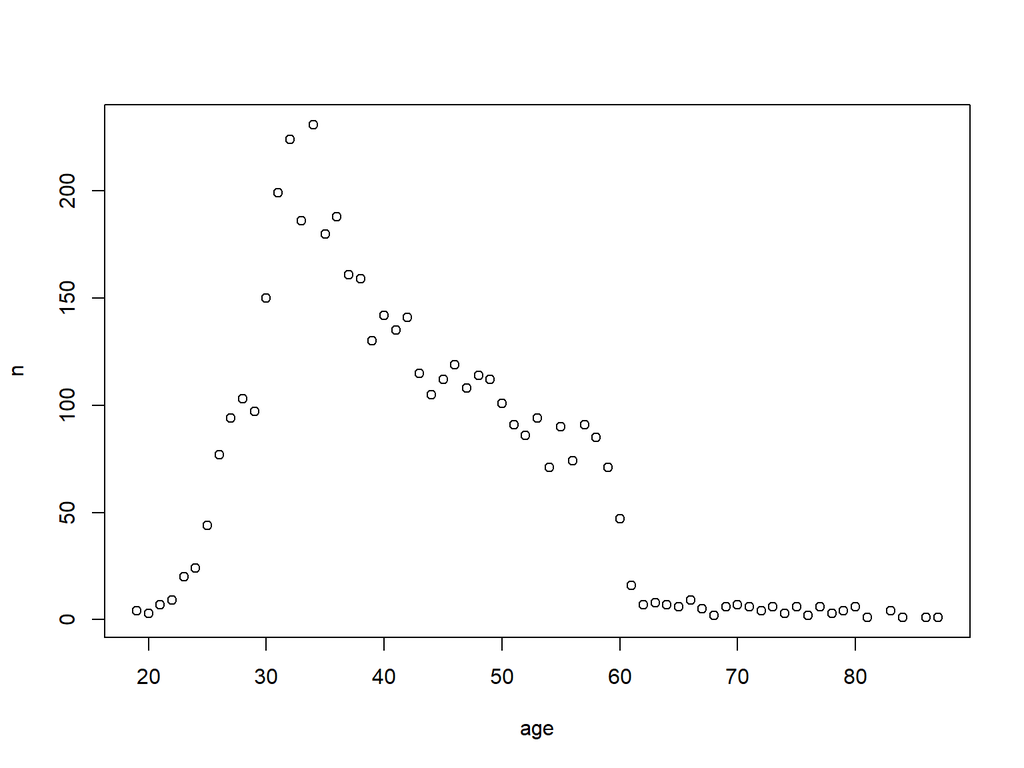

```r
group_by(bank, age) %>% summarise(n = n()) %>% plot
```

# `group_by` / `summarize`: Examples

```r
bank1 <- group_by(bank, age) %>%
  summarise(balance_mean = mean(balance),
            count = n(),
            default_count = sum(ifelse(default == "no", 0, 1)))

head(bank1)
```

| age | balance_mean | count | default_count |
| --- | --- | --- | --- |
| 19 | 393.5000 | 4 | 0 |
| 20 | 661.3333 | 3 | 0 |
| 21 | 1774.2857 | 7 | 0 |
| 22 | 1455.3333 | 9 | 0 |
| 23 | 2117.9500 | 20 | 1 |
| 24 | 634.6250 | 24 | 1 |

# `group_by` / `summarize`: Examples

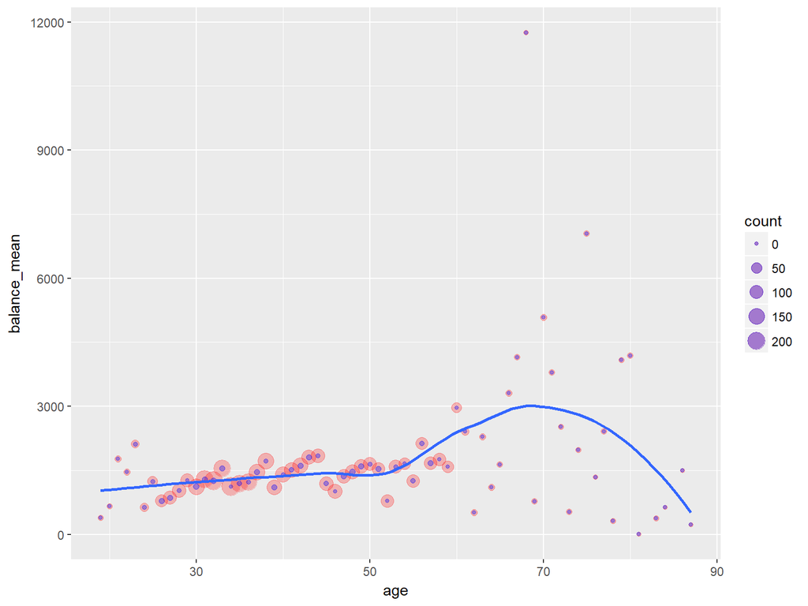

```r
# If combined with ggplot, to be learnt in next session
ggplot(bank1, aes(x = age, y = balance_mean)) +
  geom_point(aes(size = count), alpha = 1/4, color = "red") +
  geom_point(aes(size = default_count), alpha = 1/3, color = "blue") +
  geom_smooth(se = F)
## `geom_smooth()` using method = 'loess'
```

# Group filter

```r
# Find the maximum and minimum balance on each age.
bank %>%
  group_by(age) %>%
  filter(min_rank(balance) == 1 | min_rank(desc(balance)) == 1) %>%
  arrange(age, balance)
```

| age | job | marital | education | default | balance | housing | loan | contact | day | month | duration | campaign | pdays | previous | poutcome | y |
| --- | --- | --- | --- | --- | --- | --- | --- | --- | --- | --- | --- | --- | --- | --- | --- | --- |
| 19 | student | single | unknown | no | 0 | no | no | cellular | 11 | feb | 123 | 3 | -1 | 0 | unknown | no |
| 19 | student | single | unknown | no | 1169 | no | no | cellular | 6 | feb | 463 | 18 | -1 | 0 | unknown | no |
| 20 | student | single | secondary | no | 291 | no | no | telephone | 11 | may | 172 | 5 | 371 | 5 | failure | no |
| 20 | student | single | secondary | no | 1191 | no | no | cellular | 12 | feb | 274 | 1 | -1 | 0 | unknown | no |
| 21 | student | single | secondary | no | 6 | no | no | unknown | 9 | may | 622 | 1 | -1 | 0 | unknown | no |
| 21 | student | single | secondary | no | 6844 | no | no | cellular | 14 | aug | 126 | 3 | 127 | 7 | other | no |
| 22 | student | single | unknown | no | 47 | no | no | cellular | 3 | jul | 69 | 3 | -1 | 0 | unknown | no |
| 22 | admin. | single | secondary | no | 4111 | no | yes | cellular | 19 | aug | 65 | 1 | -1 | 0 | unknown | no |
| 23 | technician | single | secondary | no | -306 | yes | no | unknown | 4 | jun | 217 | 2 | -1 | 0 | unknown | no |
| 23 | student | single | secondary | no | 9216 | no | no | cellular | 5 | jun | 471 | 2 | -1 | 0 | unknown | no |

[output cut: 125 more lines]

# Count for condition

TRUE => 1, FALSE => 0

```r
# Generate a report for balance and job
d1 <- group_by(bank, job) %>%
  summarise(`balance > 500` = sum(balance > 500))
d2 <- group_by(bank, job) %>%
  summarise(`balance <= 500` = sum(balance <= 500))
# d collects all jobs, in case some jobs is missing from d1 or d2
d <- distinct(bank, job) %>% arrange(job)
d <- left_join(d, d1, by = "job")
d <- left_join(d, d2, by = "job")
d <- mutate(d, total = `balance > 500` + `balance <= 500`)
d
```

| job | balance > 500 | balance <= 500 | total |
| --- | --- | --- | --- |
| admin. | 226 | 252 | 478 |
| blue-collar | 423 | 523 | 946 |
| entrepreneur | 74 | 94 | 168 |
| housemaid | 42 | 70 | 112 |
| management | 521 | 448 | 969 |
| retired | 127 | 103 | 230 |
| self-employed | 89 | 94 | 183 |
| services | 154 | 263 | 417 |
| student | 41 | 43 | 84 |
| technician | 353 | 415 | 768 |

[output cut: 2 more lines]

# `group_by` and `summarise/summarize`: Further expository

- `group_by` is a like folding a paper without tearing it later.
- `summarise` will tear the paper.
- Therefore, `group_by` can be used with other verbs, `mutate`, `filter`, which will work within the group.
- `summarise` can be used without group_by, then it will apply to entire data as one whole group.

# `group_by`

```r
# mutate with group_by
group_by(data.frame(a = 1:10), quartile = ntile(a, 2)) %>%
  mutate(b = a / sum(a))
```

| a | quartile | b |
| --- | --- | --- |
| 1 | 1 | 0.06666667 |
| 2 | 1 | 0.13333333 |
| 3 | 1 | 0.20000000 |
| 4 | 1 | 0.26666667 |
| 5 | 1 | 0.33333333 |
| 6 | 2 | 0.15000000 |
| 7 | 2 | 0.17500000 |
| 8 | 2 | 0.20000000 |
| 9 | 2 | 0.22500000 |
| 10 | 2 | 0.25000000 |

# `group_by` / 2

```r
# filter with group_by
group_by(bank, age) %>% filter(balance == max(balance))
```

| age | job | marital | education | default | balance | housing | loan | contact | day | month | duration | campaign | pdays | previous | poutcome | y |
| --- | --- | --- | --- | --- | --- | --- | --- | --- | --- | --- | --- | --- | --- | --- | --- | --- |
| 22 | admin. | single | secondary | no | 4111 | no | yes | cellular | 19 | aug | 65 | 1 | -1 | 0 | unknown | no |
| 78 | housemaid | married | secondary | no | 499 | no | no | telephone | 16 | mar | 80 | 4 | -1 | 0 | unknown | no |
| 23 | student | single | secondary | no | 9216 | no | no | cellular | 5 | jun | 471 | 2 | -1 | 0 | unknown | no |
| 46 | management | married | secondary | no | 12186 | no | no | unknown | 20 | jun | 29 | 3 | -1 | 0 | unknown | no |
| 64 | retired | married | unknown | no | 2923 | no | no | cellular | 12 | mar | 120 | 1 | -1 | 0 | unknown | no |
| 77 | retired | married | tertiary | no | 7802 | no | no | telephone | 4 | may | 421 | 1 | 92 | 2 | success | yes |
| 39 | management | single | tertiary | no | 12437 | no | no | telephone | 18 | nov | 40 | 1 | -1 | 0 | unknown | no |
| 28 | student | single | secondary | no | 11555 | no | no | cellular | 8 | apr | 125 | 2 | -1 | 0 | unknown | no |
| 81 | retired | married | secondary | no | 1 | no | no | cellular | 19 | aug | 65 | 5 | -1 | 0 | unknown | no |
| 33 | housemaid | single | tertiary | no | 23663 | yes | no | cellular | 16 | apr | 199 | 2 | 146 | 2 | failure | no |

[output cut: 58 more lines]

# `summarize/summarise`

```r
# summarise with group_by
group_by(data.frame(a = 1:10), quartile = ntile(a, 2)) %>%
  summarise(b = sum(a))
```

| quartile | b |
| --- | --- |
| 1 | 15 |
| 2 | 40 |

```r
# summarise without a group_by
summarise(bank, with_housing = sum(housing == "yes") / n(),
          age_min = min(age),
          duration_mean = mean(duration))
```

| with_housing | age_min | duration_mean |
| --- | --- | --- |
| 0.5660252 | 19 | 263.9613 |

# group_by/rowwise/ungroup

`ungroup()` removes group definition, restores the “ungrouped”" data frame back to entire data. Because `group_by` will leave a trace

```r
# wrong
group_by(bank, age) %>%
  filter(balance == max(balance)) %>%
  summarize(balance = mean(balance)) %>%
  head(n = 3)
```

| age | balance |
| --- | --- |
| 19 | 1169 |
| 20 | 1191 |
| 21 | 6844 |

```r
# correct
group_by(bank, age) %>%
  filter(balance == max(balance)) %>%
  ungroup %>%
  summarize(balance = mean(balance))
```

| balance |
| --- |
| 13541.21 |

# group_by/rowwise/ungroup

```r
# We can't remove age
# R will prompt for "Adding missing grouping variables: `age`"
group_by(bank, age) %>%
  filter(balance == max(balance)) %>%
  select(-age) %>% head(n = 3)
## Adding missing grouping variables: `age`
```

| age | job | marital | education | default | balance | housing | loan | contact | day | month | duration | campaign | pdays | previous | poutcome | y |
| --- | --- | --- | --- | --- | --- | --- | --- | --- | --- | --- | --- | --- | --- | --- | --- | --- |
| 22 | admin. | single | secondary | no | 4111 | no | yes | cellular | 19 | aug | 65 | 1 | -1 | 0 | unknown | no |
| 78 | housemaid | married | secondary | no | 499 | no | no | telephone | 16 | mar | 80 | 4 | -1 | 0 | unknown | no |
| 23 | student | single | secondary | no | 9216 | no | no | cellular | 5 | jun | 471 | 2 | -1 | 0 | unknown | no |

```r
# We can remove age with ungroup
group_by(bank, age) %>%
  filter(balance == max(balance)) %>%
  ungroup %>%
  select(-age) %>% head(n = 3)
```

| job | marital | education | default | balance | housing | loan | contact | day | month | duration | campaign | pdays | previous | poutcome | y |
| --- | --- | --- | --- | --- | --- | --- | --- | --- | --- | --- | --- | --- | --- | --- | --- |
| admin. | single | secondary | no | 4111 | no | yes | cellular | 19 | aug | 65 | 1 | -1 | 0 | unknown | no |
| housemaid | married | secondary | no | 499 | no | no | telephone | 16 | mar | 80 | 4 | -1 | 0 | unknown | no |
| student | single | secondary | no | 9216 | no | no | cellular | 5 | jun | 471 | 2 | -1 | 0 | unknown | no |

# rowwise

Sometimes, we need to use `rowwise()` which is a special `group_by` which just makes every one row a group. Use case, it applies to complex logic that can’t be applied as a group.

```r
df <- data.frame(throw_dices = 1:10)
rowwise(df) %>% mutate( mean = mean(sample(1:6, throw_dices, replace = T)))
```

| throw_dices | mean |
| --- | --- |
| 1 | 5.000000 |
| 2 | 1.500000 |
| 3 | 2.000000 |
| 4 | 4.000000 |
| 5 | 3.000000 |
| 6 | 3.833333 |
| 7 | 4.142857 |
| 8 | 3.000000 |
| 9 | 3.888889 |
| 10 | 4.200000 |

# `bind_rows`

- bind_rows is the `+` operator for data frames.

```r
# add empty data frame is the same.
bind_rows(data.frame(a = 3:4), data.frame())
```

| a |
| --- |
| 3 |
| 4 |

```r
bind_rows(data.frame(), data.frame(a = 3:4))
```

| a |
| --- |
| 3 |
| 4 |

# `bind_rows`: Use case

I usually use bind_rows to collect results. For example,

```
new_positions <- data.frame()
closed_positions <- data.frame()

for (i in length(dates)-1) {
  old_date <- dates[i]
  new_date <- dates[i+1]

  new_data <- filter(position, date == new_date)
  old_data <- filter(position, date == old_date)

  new_positions <- bind_rows(new_positions,
                             anti_join(new_data, old_data, by = "position_id"))
}

# new_positions contains all new positions on day 1
```

# `bind_rows`: Use case

If row order matters, bind_row can be used to re-order/splice and recombine.

```r
# Get head and tail
# Note: use { } to use the .
arrange(bank, age) %>%
{ bind_rows(head(., n = 5), tail(., n = 5)) }
```

| age | job | marital | education | default | balance | housing | loan | contact | day | month | duration | campaign | pdays | previous | poutcome | y |
| --- | --- | --- | --- | --- | --- | --- | --- | --- | --- | --- | --- | --- | --- | --- | --- | --- |
| 19 | student | single | primary | no | 103 | no | no | cellular | 10 | jul | 104 | 2 | -1 | 0 | unknown | yes |
| 19 | student | single | unknown | no | 0 | no | no | cellular | 11 | feb | 123 | 3 | -1 | 0 | unknown | no |
| 19 | student | single | secondary | no | 302 | no | no | cellular | 16 | jul | 205 | 1 | -1 | 0 | unknown | yes |
| 19 | student | single | unknown | no | 1169 | no | no | cellular | 6 | feb | 463 | 18 | -1 | 0 | unknown | no |
| 20 | student | single | secondary | no | 502 | no | no | cellular | 30 | apr | 261 | 1 | -1 | 0 | unknown | yes |
| 83 | retired | divorced | primary | no | 0 | no | no | telephone | 31 | may | 664 | 1 | 77 | 3 | success | no |
| 83 | retired | divorced | primary | no | 1097 | no | no | telephone | 5 | mar | 181 | 1 | -1 | 0 | unknown | yes |
| 84 | retired | divorced | primary | no | 639 | no | no | telephone | 18 | may | 353 | 3 | -1 | 0 | unknown | yes |
| 86 | retired | married | secondary | no | 1503 | no | no | telephone | 18 | mar | 165 | 3 | 101 | 1 | other | no |
| 87 | retired | married | primary | no | 230 | no | no | cellular | 30 | oct | 144 | 1 | -1 | 0 | unknown | yes |

# `bind_rows`: Use case

```r
# summary
summarise_if(bank, is.numeric, mean)
```

| age | balance | day | duration | campaign | pdays | previous |
| --- | --- | --- | --- | --- | --- | --- |
| 41.1701 | 1422.658 | 15.91528 | 263.9613 | 2.79363 | 39.76664 | 0.5425791 |

```r
# add summary to the records
tail(bind_rows(bank, summarise_if(bank, is.numeric, mean)), n = 1)
```

|  | age | job | marital | education | default | balance | housing | loan | contact | day | month | duration | campaign | pdays | previous | poutcome | y |
| --- | --- | --- | --- | --- | --- | --- | --- | --- | --- | --- | --- | --- | --- | --- | --- | --- | --- |
| 4522 | 41.1701 | NA | NA | NA | NA | 1422.658 | NA | NA | NA | 15.91528 | NA | 263.9613 | 2.79363 | 39.76664 | 0.5425791 | NA | NA |

# `bind_rows`: Use case

```r
# bind_rows can match column names and type.
# let's adjust the column order.
# As due-deligence, better to check the result.
# I remember earlier version of dplyr doesn't do match.
tail(bind_rows(bank, summarise_if(bank, is.numeric, mean) %>%
  select(balance, day, everything())), n = 1)
```

|  | age | job | marital | education | default | balance | housing | loan | contact | day | month | duration | campaign | pdays | previous | poutcome | y |
| --- | --- | --- | --- | --- | --- | --- | --- | --- | --- | --- | --- | --- | --- | --- | --- | --- | --- |
| 4522 | 41.1701 | NA | NA | NA | NA | 1422.658 | NA | NA | NA | 15.91528 | NA | 263.9613 | 2.79363 | 39.76664 | 0.5425791 | NA | NA |

# bind_cols

- bind_cols is to extend the data frame in width.

Use cases - It’s a lazyman’s `left_join` or `select` - It copies the columns - I usually find it useful to generate data frame for reports.

```r
dt1 <- bind_cols(select(bank, job), select(bank, education))
dt1[1:3,]
```

|  | job | education |
| --- | --- | --- |
| 1 | unemployed | primary |
| 2 | services | secondary |
| 3 | management | tertiary |

# bind_cols

```r
dt2 <- bind_cols(dt1, dt1)
dt2[1:3,]
```

|  | job | education | job1 | education1 |
| --- | --- | --- | --- | --- |
| 1 | unemployed | primary | unemployed | primary |
| 2 | services | secondary | services | secondary |
| 3 | management | tertiary | management | tertiary |

# bind_cols: Use cases

```r
d1 <- filter(bank, month == "sep") %>%
  summarize(duration = mean(duration)) %>%
  rename(`Duration Sep` = duration)
d2 <- filter(bank, month == "oct") %>%
  summarize(duration = mean(duration)) %>%
  rename(`Duration Oct` = duration)
d3 <- filter(bank, month == "nov") %>%
  summarize(duration = mean(duration)) %>%
  rename(`Duration Nov` = duration)

bind_cols(d1, d2, d3)
```

| Duration Sep | Duration Oct | Duration Nov |
| --- | --- | --- |
| 215.7308 | 272.8 | 272.0668 |

# Exercise

1. How to know the row number of the wrong date

```r
df <- data.frame(x = c("2017-10-01", "2017-31-12", "2017-03-17", "2017-02-29", "2017-09-30"))
df
```

| x |
| --- |
| 2017-10-01 |
| 2017-31-12 |
| 2017-03-17 |
| 2017-02-29 |
| 2017-09-30 |

Output:

```
## Wrong dates on: 2, 4
```

# Exercise

   | job | education | mean(Age) | median(Balance) |
   | --- | --- | --- | --- |
   | services | primary | … | … |
   | services |  |  |  |
   | services | + | … | … |
   | … |  |  |  |
   | + | + | … | … |

# Exercise

3. To evaluate a portfolio of options for its total value.

```r
GBSOption(TypeFlag = "p", S = 3500, X = 3765,
          Time = 1/12, r = 0, b = 0, sigma = 0.3)@price
## [1] 300.0049
df <- data.frame(type = sample(c("c", "p"), 100, replace = T),
                 strike = round(runif(100) * 100, 0),
                 underlying = round(runif(100) * 100, 0),
                 Time = 1,
                 r = 0.01,
                 b = 0,
                 sigma = 0.3)
```

# tidyr: gather/spread

Wide format <=> Long format

- Wide format is more familiar to us. Column name is the data attribute.
- Long format is what we reformat the data that common attributes are gathered together as a single variable.
- Reference: Tidy data https://en.wikipedia.org/wiki/Tidy_data

# Wide v.s. Long

## Wide format

| date | Copper_qty | Gold_qty | Silver_qty |
| --- | --- | --- | --- |
| 2017-01-01 | 127 | 261 | 500 |
| 2017-01-02 | 490 | 538 | 567 |
| 2017-01-03 | 393 | 306 | 802 |
| 2017-01-04 | 234 | 356 | 684 |
| 2017-01-05 | 177 | 664 | 869 |

## Long format

| date | key | value |
| --- | --- | --- |
| 2017-01-01 | Copper_qty | 127 |
| 2017-01-02 | Copper_qty | 490 |
| 2017-01-03 | Copper_qty | 393 |
| 2017-01-04 | Copper_qty | 234 |
| 2017-01-05 | Copper_qty | 177 |
| 2017-01-01 | Gold_qty | 261 |
| 2017-01-02 | Gold_qty | 538 |
| 2017-01-03 | Gold_qty | 306 |
| 2017-01-04 | Gold_qty | 356 |
| 2017-01-05 | Gold_qty | 664 |

[output cut: 5 more lines]

# `spread/gather` conversion for Wide format <=> Long format

```
gather(data, key, value, ...)
```

… is where you want to make as independent columns. You need to specify all columns that should be gathers (or remove all columns that should _not_be gathered): pdf

```r
mini_iris <- iris[1:3,]
gather(mini_iris,
       key = flower_att,
       value = measurement,
       -Species)
```

| Species | flower_att | measurement |
| --- | --- | --- |
| setosa | Sepal.Length | 5.1 |
| setosa | Sepal.Length | 4.9 |
| setosa | Sepal.Length | 4.7 |
| setosa | Sepal.Width | 3.5 |
| setosa | Sepal.Width | 3.0 |
| setosa | Sepal.Width | 3.2 |
| setosa | Petal.Length | 1.4 |
| setosa | Petal.Length | 1.4 |
| setosa | Petal.Length | 1.3 |
| setosa | Petal.Width | 0.2 |

[output cut: 2 more lines]

# `spread/gather` what columns to remove/add

```r
lfmt <- gather(mini_iris,
               key = flower_att,
               value = measurement,
               Sepal.Length, Sepal.Width, Petal.Length, Petal.Width)
lfmt
```

| Species | flower_att | measurement |
| --- | --- | --- |
| setosa | Sepal.Length | 5.1 |
| setosa | Sepal.Length | 4.9 |
| setosa | Sepal.Length | 4.7 |
| setosa | Sepal.Width | 3.5 |
| setosa | Sepal.Width | 3.0 |
| setosa | Sepal.Width | 3.2 |
| setosa | Petal.Length | 1.4 |
| setosa | Petal.Length | 1.4 |
| setosa | Petal.Length | 1.3 |
| setosa | Petal.Width | 0.2 |

[output cut: 2 more lines]

# Spread

```
spread(lfmt, key, value)
```

Example: get row sum.

```r
library(tidyr)
wfmt %>%
  gather(key, value, -date) %>%
  group_by(date) %>%
  summarize(value1 = sum(value)) %>%
  rename(value = value1) %>%
  mutate(key = "Total") %>%
  spread(key = key, value = value) %>%
  inner_join(wfmt, ., by = "date")
```

| date | Copper_qty | Gold_qty | Silver_qty | Total |
| --- | --- | --- | --- | --- |
| 2017-01-01 | 127 | 261 | 500 | 888 |
| 2017-01-02 | 490 | 538 | 567 | 1595 |
| 2017-01-03 | 393 | 306 | 802 | 1501 |
| 2017-01-04 | 234 | 356 | 684 | 1274 |
| 2017-01-05 | 177 | 664 | 869 | 1710 |

```r
# although this works...
# Hard coding of column names "Copper_qty Gold_qty Silver_qty".
wfmt %>% mutate(total = Copper_qty + Gold_qty + Silver_qty)
```

| date | Copper_qty | Gold_qty | Silver_qty | total |
| --- | --- | --- | --- | --- |
| 2017-01-01 | 127 | 261 | 500 | 888 |
| 2017-01-02 | 490 | 538 | 567 | 1595 |
| 2017-01-03 | 393 | 306 | 802 | 1501 |
| 2017-01-04 | 234 | 356 | 684 | 1274 |
| 2017-01-05 | 177 | 664 | 869 | 1710 |

# `separate/unite`

```
separate(data, col, into, sep = "[^[:alnum:]]+", remove = TRUE,
  convert = FALSE, extra = "warn", fill = "warn", ...)

#> # A tibble: 6 × 3
#>       country  year              rate
#> *       <chr> <int>             <chr>
#> 1 Afghanistan  1999      745/19987071
#> 2 Afghanistan  2000     2666/20595360
#> 3      Brazil  1999   37737/172006362
#> 4      Brazil  2000   80488/174504898
#> 5       China  1999 212258/1272915272
#> 6       China  2000 213766/1280428583

separate(df, rate, into = c("cases", "population"))
separate(df, rate, into = c("cases", "population"), convert = TRUE)

unite(df, century, year) # default sep is "_"
unite(df, century, year, sep = "") # seamless unite
```

# Rules of Thumb for design data storage

- Use list to store app data, i.e. configuration.
- User data frame to store repeating data of similar structure
- Every data frame is better to have a column with the function of **item_id**. It can be number or character. Make it unique. If **item_id** is a number, when insert new record to the data frame, we need to increment it somewhere. So, store it somewhere.
- Delete is not good for customer data. add a column name with a common name, e.g. SYS_DEL.

  ```
  | position_id | call_put | amount | strike | SYS_DEL |
  | X123        |          |        |        |
  ```

# CRUD in dplyr

Create:

- add new rows. bind_rows()

Read:

- You have known enough: filter/select/joins/… to get what you need.

Update:

- Use either data frame way or mutate.

```
# get all row numbers for students
row_nums <- mutate(bank, nnn = 1:n()) %>%
            filter(job == "student" & age < 22) %>%
            select(nnn) %>%
            .$nnn

bank1 <- bank
bank1[row_nums, "taxable"] <- "no"
bank1[setdiff(1:nrow(bank), row_nums), "taxable"] <- "yes"

# use dplyr
bank1 <- mutate(bank, taxable = ifelse(job == "student" & age < 22, "no", "yes"))
distinct(bank1, taxable)
```

Delete:

- Use filter to exclude the row(s).
- (Advanced version) Create a column `DELETED` of logic type, if we need to delete the row, set it T. We need to change all read commands to have `!DELETED`

# Assignment

1. Exploratory Data Work on the bank dataset. Find 10 findings from data. Use R Markdown.

````
---
title: "FE8828 Assignment for Exploratory Data Analysis"
author: "Yang Ye <sub> <Email:yy@runchee.com> </sub>"
date: "Nov 15, 2017"
output: html_document
---

```{r setup, include=FALSE}
library(tidyverse)
library(lubridate)
library(bizdays)
knitr::opts_chunk$set(echo = FALSE, fig.align="center", collapse = TRUE, cache = T)
bank <- read.csv("https://goo.gl/PBQnBt", sep = ";")
```

# Finding #1
This data contains `r nrow(data)` rows.

# Finding #2
```{r, echo = F}
# Find the big age group
bank %>%
  group_by(age_group = (age %/% 10) * 10) %>%
  summarise(count = n()) %>%
  arrange(age_group) -> res

res

plot(res$age_group, res$count)
```

# Discover insights of data
- Employment
- Social attributes.
- Count for sub-total / total, plot graph
````

# Assignment

2. Book option trades

1.1 Store the options from https://finance.google.com/finance/option_chain?q=NASDAQ%3AAMZN&ei=iIoAWvDmF8GqugSsj5mICw

```
    | Date | Strike | Quantity | Underlying | Long/Short | Call/Put
```

1.2 Count the total valuation of call alone, put alone, call and put.

1.3 Find those in the money.

1.4. Plot the volatility curve, strike v.s. vol

```r
# GBSVolatility(price, TypeFlag, S, X, Time, r, b, tol, maxiter)
# Use Price to back-out implied volatility
GBSVolatility(867.30, "c", 1135.67, 240,
              as.numeric((as.Date("2018-01-19") - as.Date("2017-11-15")))/365, r = 0.01, b = 0)
## [1] 8.101273e-18
GBSVolatility(256.50, "c", 1135.67, 880.00,
              as.numeric((as.Date("2018-01-19") - as.Date("2017-11-15")))/365, r = 0.01, b = 0)
## [1] 0.3107899
GBSVolatility(53.62, "c", 1135.67, 1120.00,
              as.numeric((as.Date("2018-01-19") - as.Date("2017-11-15")))/365, r = 0.01, b = 0)
## [1] 0.2394823
```

# Assignment

3. Bank (Group - choose a coordinator to send me the report) This is the 1st installment of the assignment. There will be more installment. Due on 6th week. Please pace your group.

   ```
   Data frame 1: Account
   | AcountNo | Name |

   Data frame 2: Transaction
   | TransactionNo | Date | AccountNo | TransactionType | Amount | Currency |

   Data frame 3: Currency to SGD
   | Currency | Conversion | Date |
   ```

TransactionType can be: Withdraw/Deposit/Spend Write follow functions and use them to initialize the data.

1. Create 10 accounts with initial random deposit and credit in SGD.
2. Create 3 currencies: CNY, USD, SGD. Download their conversion rate between 2017-07-01 and 2017-09-30.
3. Generate random transaction data for 10 accounts during 2017-07-01 and 2017-09-30. Make it more realistic, deposite is 1-2 times per month, a random number of 3000-5000. Spend/Withdraw can be any times and any amount. Deposit is positive, Withdraw/Spend is negative. You can’t withdraw more than the deposit, can’t spend more than credit + deposit.
4. Generate report for transaction as month-end statement in SGD.

   ```
   { Client Name }
   { Month }

   # Transaction History

   Date | TransactionType | Amount | Currency | Deposit Balance | Credit Balance |
        |                 |        |          |                 |                |
        |                 |        |          |                 |                |
        |                 |        |          |                 |                |
   -------------------------------------------------------------------------------
                            Month-End Balance | Deposit         | Credit         |

   # Summary

   TransactionType | Amount |
   ...
   ```

Submission:

1. A report describing interesting learning points on design and coding (1-2 pages, just be concise)
2. Code with decent amount of comments
3. Example running result.